# 3a_analyse_no_controls

Thomas E. Metherell

25/08/2021

This script analyses the cleaned data from Understanding Society dataset for use in our study of digital exclusion and adolescent mental health during the COVID-19 pandemic in the United Kingdom.

The focus of this analysis is fitting latent growth models to longitudinal SDQ data, including divided by access to a computer and to a good internet connection, without covariates.

# Dependencies

We start by loading the necessary dependencies.

```r
library(tidyverse)
library(magrittr)
library(PupillometryR)
library(lavaan)
library(survey)
library(lavaan.survey)
library(scales)
```

```r
library(cowplot)
library(semTable)
```

# Loading the data

We can now load the cleaned dataset (long and wide versions), and select the waves and variables that are relevant to this analysis.

```r
# Loading long dataset
data_full <- read.csv("Data/Cleaned/data.csv", quote = "")

# Loading wide dataset
data_wide <- read.csv("Data/Cleaned/data_wide.csv", quote = "")

# Selecting relevant variables and storing those in data_rel (long data)
data_rel <- data_full[data_full$wave == "W9" | data_full$wave == "CV4" | data_full$wave == "CV6" | data_full$wave == "CV8",] %>%
  dplyr::select(
    contains("ypsdqtd_dv"), # SDQ summary scores
    wave, # Wave
    pidp, # Participant ID
    ageon20200815, # Age on 15/08/2020
    sex_merged, # Sex
    contains("ypschlth"), # Digital inclusion variables
    contains("betayth_lw") # Beta-version longitudinal weights
  )

# Selecting relevant variables and storing those in data_rel_wide (wide data)
data_rel_wide <- data_wide %>%
  dplyr::select(
    contains("ypsdqtd_dv"), # SDQ summary scores
    pidp, # Participant ID
    ageon20200815, # Age on 15/08/2020
    sex_merged, # Sex
    ethn_dv, # Ethnicity
    contains("ypschlth"), # Digital inclusion variables
    contains("betayth_lw"), # Beta-version longitudinal weights
  )

# Removing full datasets
rm(data_full)
rm(data_wide)
```

# Recoding variables

We redefine wave, sex and digital inclusion variables as factors in the long data.

```r
data_rel$wave <- factor(data_rel$wave, levels = c("W9", "CV4", "CV6", "CV8"))

data_rel$sex_merged <- factor(data_rel$sex_merged)
levels(data_rel$sex_merged) <- c("Male", "Female")

data_rel$ypschlth1 <- factor(data_rel$ypschlth1)
levels(data_rel$ypschlth1) <- c("No", "Yes")
data_rel$ypschlth2 <- factor(data_rel$ypschlth2)
levels(data_rel$ypschlth2) <- c("No", "Yes")
```

# Creating dataset for latent growth models

We specify the data frame `data_sdq`, which contains the data needed for fitting LGMs.

```r
# Creating dataset for LGM fitting
data_sdq <- data_rel_wide %>%
  dplyr::select(
    pidp, # Participant ID
    contains("ypsdqtd_dv"), # Total Difficulties score
    betayth_lw_CV8, # CV8 longitudinal weight
    ypschlth1, # Access to a computer
    ypschlth2, # Access to a good internet connection
  )

# Renaming SDQ variables to the wave identifiers
names(data_sdq) <- str_replace(names(data_sdq), "ypsdqtd_dv_", "")

# Excluding participants with no CV8 longitudinal weight
data_sdq <- data_sdq[!is.na(data_sdq$betayth_lw_CV8),]

# Specifying survey weights
survey_design <- svydesign(~0, data = data_sdq, weights = data_sdq$betayth_lw_CV8)
```

# Descriptive plots

We illustrate the mean SDQ scores across the four relevant waves.

```
##
## ### SDQ summary data
```

```
##   wave     mean       sd    n        se      min      max
## 1   W9 10.70262 5.932027 2791 0.1122854 10.59033 10.81490
## 2  CV4 10.91329 6.021147 1407 0.1605211 10.75277 11.07381
## 3  CV6 11.39845 6.330839 1423 0.1678258 11.23063 11.56628
## 4  CV8 11.06277 6.137271 1386 0.1648518 10.89792 11.22762
```

```
##
## ### Mean Total Difficulties scores with standard error
```

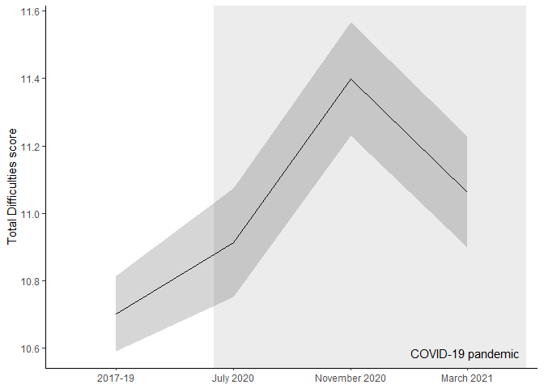

### Mean Total Difficulties scores with individual trajectories

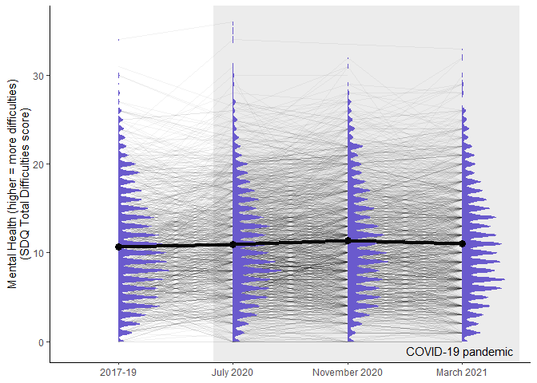

# Fitting initial LGM

We now fit a latent growth model to the whole-cohort SDQ data, using pairwise $\chi^2$ tests ($\alpha$ = 0.05) to compare models and accordingly accept or reject sequential changes.

```r
# Fitting no-change model
lgm_sdq_nc <- '
i =~ 1*W9 + 1*CV4 + 1*CV6 + 1*CV8
'

fit_lgm_sdq_nc <- growth(lgm_sdq_nc, data = data_sdq, missing = "fiml")
# Fitting linear model
lgm_sdq_lin <- '
i =~ 1*W9 + 1*CV4 + 1*CV6 + 1*CV8
s =~ 0*W9 + 1*CV4 + 2*CV6 + 3*CV8
'

fit_lgm_sdq_lin <- growth(lgm_sdq_lin, data = data_sdq, missing = "fiml")
# Comparing linear to no-change model
anova(fit_lgm_sdq_lin, fit_lgm_sdq_nc)
```

```
## Chi-Squared Difference Test
##
##                 Df   AIC   BIC   Chisq Chisq diff Df diff Pr(>Chisq)
## fit_lgm_sdq_lin  5 21961 22008  34.739
## fit_lgm_sdq_nc   8 22101 22133 181.581     146.84       3  < 2.2e-16 ***
## ---
## Signif. codes:  0 '***' 0.001 '**' 0.01 '*' 0.05 '.' 0.1 ' ' 1
```

```r
# Accepting linear over no-change model

# Fitting quadratic model
lgm_sdq_quad <- '
i =~ 1*W9 + 1*CV4 + 1*CV6 + 1*CV8
s =~ 0*W9 + 1*CV4 + 2*CV6 + 3*CV8
q =~ 0*W9 + 1*CV4 + 4*CV6 + 9*CV8
'

fit_lgm_sdq_quad <- growth(lgm_sdq_quad, data = data_sdq, missing = "fiml")
# Comparing quadratic to linear model
anova(fit_lgm_sdq_quad, fit_lgm_sdq_lin)
```

```
## Chi-Squared Difference Test
##
##                  Df   AIC   BIC   Chisq Chisq diff Df diff Pr(>Chisq)
## fit_lgm_sdq_quad  1 21934 22002  0.1572
## fit_lgm_sdq_lin   5 21961 22008 34.7386     34.581       4  5.662e-07 ***
## ---
## Signif. codes:  0 '***' 0.001 '**' 0.01 '*' 0.05 '.' 0.1 ' ' 1
```

```r
# Accepting quadratic over linear model

# Applying weights to model
fit_weighted <- lavaan.survey(fit_lgm_sdq_quad, survey_design, estimator = "ML")
# Summary of weighted model
summary(fit_weighted)
```

```
## lavaan 0.6-9 ended normally after 83 iterations
##
##   Estimator                                         ML
##   Optimization method                           NLMINB
##   Number of model parameters                        13
##
##   Number of observations                          1387
##
## Model Test User Model:
##
##   Test statistic                                 7.876
##   Degrees of freedom                                 1
##   P-value (Chi-square)                           0.005
##
## Parameter Estimates:
##
##   Standard errors                             Standard
##   Information                                 Observed
##   Observed information based on                Hessian
##
## Latent Variables:
##                    Estimate  Std.Err  z-value  P(>|z|)
##   i =~
##     W9                1.000
##     CV4               1.000
##     CV6               1.000
##     CV8               1.000
##   s =~
##     W9                0.000
##     CV4               1.000
##     CV6               2.000
##     CV8               3.000
##   q =~
##     W9                0.000
##     CV4               1.000
##     CV6               4.000
##     CV8               9.000
##
## Covariances:
##                    Estimate  Std.Err  z-value  P(>|z|)
```

[output cut: 10 more lines]

```
##    .CV6               0.000
##    .CV8               0.000
##     i                10.098    0.148   68.098    0.000
##     s                 1.117    0.143    7.835    0.000
##     q                -0.263    0.040   -6.554    0.000
##
## Variances:
##                    Estimate  Std.Err  z-value  P(>|z|)
##    .W9               10.318    1.851    5.575    0.000
##    .CV4               6.258    0.627    9.981    0.000
##    .CV6               9.030    0.711   12.698    0.000
##    .CV8               0.909    1.918    0.474    0.636
##     i                20.720    1.971   10.510    0.000
##     s                 7.325    2.288    3.201    0.001
##     q                 0.569    0.146    3.899    0.000
```

```r
# Producing model output table and exporting to CSV
vlabs <- c("W9" = "Main study wave 9", "CV4" = "COVID-19 wave 4", "CV6" = "COVID-19 wave 6", "CV8" = "COVID-19 wave 8", "i" = "Intercept", "s" = "Linear coefficient", "q" = "Quadratic coefficient")
semTable(fit_weighted, columns = c("estse", "p"), paramSets = c("latentmeans", "latentvariances", "latentcovariances", "residualvariances"), fits = c("chisq", "cfi", "rmsea"), varLabels = vlabs, file = "Data/Objects/undiff_table.csv", type = "csv", print.results = FALSE)
```

```r
# Saving model fit object
saveRDS(fit_weighted, file = "Data/Objects/undiff.rds")

# Preparing LGM function for plotting
pT <- parTable(fit_weighted)
fit_weighted_fn <- function(x) pT[pT$lhs == "i" & pT$op == "~1",]$est + pT[pT$lhs == "s" & pT$op == "~1",]$est*x + pT[pT$lhs == "q" & pT$op == "~1",]$est*x^2

# Using model parameters to predict individual trajectories
indiv_traj <- data.frame(predict(fit_lgm_sdq_quad))
i <- nrow(indiv_traj)
```

### Final LGM with predicted individual trajectories

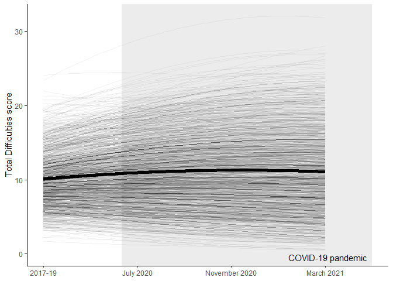

# Grouping by computer access

We now fit a new LGM with the participants grouped by whether or not they have access to a computer.

```r
# Fitting free model
model_comp_free <- '
i =~ 1*W9 + 1*CV4 + 1*CV6 + 1*CV8
s =~ 0*W9 + 1*CV4 + 2*CV6 + 3*CV8
q =~ 0*W9 + 1*CV4 + 4*CV6 + 9*CV8
'

fit_comp_free <- growth(model_comp_free, data = data_sdq[!is.na(data_sdq$ypschlth1),], group = "ypschlth1", missing = "fiml", estimator = "mlr")
# Fitting model with error variances constrained to equality
model_comp_con_ervar <- '
i =~ 1*W9 + 1*CV4 + 1*CV6 + 1*CV8
s =~ 0*W9 + 1*CV4 + 2*CV6 + 3*CV8
q =~ 0*W9 + 1*CV4 + 4*CV6 + 9*CV8

W9 ~~ c(ervar1_1, ervar1_1)*W9
CV4 ~~ c(ervar2_1, ervar2_1)*CV4
CV6 ~~ c(ervar3_1, ervar3_1)*CV6
CV8 ~~ c(ervar4_1, ervar4_1)*CV8
'

fit_comp_con_ervar <- growth(model_comp_con_ervar, data = data_sdq[!is.na(data_sdq$ypschlth1),], group = "ypschlth1", missing = "fiml", estimator = "mlr")

# Comparing model with constrained error variances to free model
anova(fit_comp_con_ervar, fit_comp_free)
```

```
## Scaled Chi-Squared Difference Test (method = "satorra.bentler.2001")
##
## lavaan NOTE:
##     The "Chisq" column contains standard test statistics, not the
##     robust test that should be reported per model. A robust difference
##     test is a function of two standard (not robust) statistics.
##
##                    Df   AIC   BIC  Chisq Chisq diff Df diff Pr(>Chisq)
## fit_comp_free       2 15934 16057 5.9176
## fit_comp_con_ervar  6 15929 16033 8.8767     3.0985       4     0.5415
```

```r
# Accepting model with constrained error variances over free model

# Fitting model with constrained y-intercept
model_comp_con_ervar_i <- '
i =~ 1*W9 + 1*CV4 + 1*CV6 + 1*CV8
s =~ 0*W9 + 1*CV4 + 2*CV6 + 3*CV8
q =~ 0*W9 + 1*CV4 + 4*CV6 + 9*CV8

W9 ~~ c(ervar1_1, ervar1_1)*W9
CV4 ~~ c(ervar2_1, ervar2_1)*CV4
CV6 ~~ c(ervar3_1, ervar3_1)*CV6
CV8 ~~ c(ervar4_1, ervar4_1)*CV8

i ~ c(i_1, i_1)*1
'

fit_comp_con_ervar_i <- growth(model_comp_con_ervar_i, data = data_sdq[!is.na(data_sdq$ypschlth1),], group = "ypschlth1", missing = "fiml", estimator = "mlr")

# Comparing model with constrained y-intercept to model without
anova(fit_comp_con_ervar_i, fit_comp_con_ervar)
```

```
## Scaled Chi-Squared Difference Test (method = "satorra.bentler.2001")
##
## lavaan NOTE:
##     The "Chisq" column contains standard test statistics, not the
##     robust test that should be reported per model. A robust difference
##     test is a function of two standard (not robust) statistics.
##
##                      Df   AIC   BIC  Chisq Chisq diff Df diff Pr(>Chisq)
## fit_comp_con_ervar    6 15929 16033 8.8767
## fit_comp_con_ervar_i  7 15928 16027 9.9948      1.104       1     0.2934
```

```r
# Accepting model with constrained y-intercept over model without

# Fitting model with constrained linear coefficient
model_comp_con_ervar_i_s <- '
i =~ 1*W9 + 1*CV4 + 1*CV6 + 1*CV8
s =~ 0*W9 + 1*CV4 + 2*CV6 + 3*CV8
q =~ 0*W9 + 1*CV4 + 4*CV6 + 9*CV8

W9 ~~ c(ervar1_1, ervar1_1)*W9
CV4 ~~ c(ervar2_1, ervar2_1)*CV4
CV6 ~~ c(ervar3_1, ervar3_1)*CV6
CV8 ~~ c(ervar4_1, ervar4_1)*CV8

i ~ c(i_1, i_1)*1
s ~ c(s_1, s_1)*1
'

fit_comp_con_ervar_i_s <- growth(model_comp_con_ervar_i_s, data = data_sdq[!is.na(data_sdq$ypschlth1),], group = "ypschlth1", missing = "fiml", estimator = "mlr")

# Comparing model with constrained linear coefficient to model without
anova(fit_comp_con_ervar_i_s, fit_comp_con_ervar_i)
```

```
## Scaled Chi-Squared Difference Test (method = "satorra.bentler.2001")
##
## lavaan NOTE:
##     The "Chisq" column contains standard test statistics, not the
##     robust test that should be reported per model. A robust difference
##     test is a function of two standard (not robust) statistics.
##
##                        Df   AIC   BIC   Chisq Chisq diff Df diff Pr(>Chisq)
## fit_comp_con_ervar_i    7 15928 16027  9.9948
## fit_comp_con_ervar_i_s  8 15930 16024 14.1829     7.4321       1   0.006407 **
## ---
## Signif. codes:  0 '***' 0.001 '**' 0.01 '*' 0.05 '.' 0.1 ' ' 1
```

```r
# Rejecting model with constrained linear coefficient

# Fitting model with constrained quadratic coefficient
model_comp_con_ervar_i_q <- '
i =~ 1*W9 + 1*CV4 + 1*CV6 + 1*CV8
s =~ 0*W9 + 1*CV4 + 2*CV6 + 3*CV8
q =~ 0*W9 + 1*CV4 + 4*CV6 + 9*CV8

W9 ~~ c(ervar1_1, ervar1_1)*W9
CV4 ~~ c(ervar2_1, ervar2_1)*CV4
CV6 ~~ c(ervar3_1, ervar3_1)*CV6
CV8 ~~ c(ervar4_1, ervar4_1)*CV8

i ~ c(i_1, i_1)*1
q ~ c(q_1, q_1)*1
'

fit_comp_con_ervar_i_q <- growth(model_comp_con_ervar_i_q, data = data_sdq[!is.na(data_sdq$ypschlth1),], group = "ypschlth1", missing = "fiml", estimator = "mlr")

# Comparing model with constrained quadratic coefficient to model without
anova(fit_comp_con_ervar_i_q, fit_comp_con_ervar_i)
```

```
## Scaled Chi-Squared Difference Test (method = "satorra.bentler.2001")
##
## lavaan NOTE:
##     The "Chisq" column contains standard test statistics, not the
##     robust test that should be reported per model. A robust difference
##     test is a function of two standard (not robust) statistics.
##
##                        Df   AIC   BIC   Chisq Chisq diff Df diff Pr(>Chisq)
## fit_comp_con_ervar_i    7 15928 16027  9.9948
## fit_comp_con_ervar_i_q  8 15930 16025 14.2037     8.5208       1   0.003511 **
## ---
## Signif. codes:  0 '***' 0.001 '**' 0.01 '*' 0.05 '.' 0.1 ' ' 1
```

```r
# Rejecting model with constrained quadratic coefficient
fit_comp_prov <- fit_comp_con_ervar_i

# Fitting model with constrained y-intercept variance
model_comp_con_ivar <- '
i =~ 1*W9 + 1*CV4 + 1*CV6 + 1*CV8
s =~ 0*W9 + 1*CV4 + 2*CV6 + 3*CV8
q =~ 0*W9 + 1*CV4 + 4*CV6 + 9*CV8

W9 ~~ c(ervar1_1, ervar1_1)*W9
CV4 ~~ c(ervar2_1, ervar2_1)*CV4
CV6 ~~ c(ervar3_1, ervar3_1)*CV6
CV8 ~~ c(ervar4_1, ervar4_1)*CV8

i ~ c(i_1, i_1)*1

i ~~ c(ivar_1, ivar_1)*i
'

fit_comp_con_ivar <- growth(model_comp_con_ivar, data = data_sdq[!is.na(data_sdq$ypschlth1),], group = "ypschlth1", missing = "fiml", estimator = "mlr")

# Comparing model with constrained y-intercept variance to model without
anova(fit_comp_con_ivar, fit_comp_prov)
```

```
## Scaled Chi-Squared Difference Test (method = "satorra.bentler.2001")
##
## lavaan NOTE:
##     The "Chisq" column contains standard test statistics, not the
##     robust test that should be reported per model. A robust difference
##     test is a function of two standard (not robust) statistics.
##
##                   Df   AIC   BIC   Chisq Chisq diff Df diff Pr(>Chisq)
## fit_comp_prov      7 15928 16027  9.9948
## fit_comp_con_ivar  8 15927 16021 11.0418     1.0172       1     0.3132
```

```r
# Accepting model with constrained y-intercept variance over model without

# Fitting model with constrained linear coefficient variance
model_comp_con_ivar_svar <- '
i =~ 1*W9 + 1*CV4 + 1*CV6 + 1*CV8
s =~ 0*W9 + 1*CV4 + 2*CV6 + 3*CV8
q =~ 0*W9 + 1*CV4 + 4*CV6 + 9*CV8

W9 ~~ c(ervar1_1, ervar1_1)*W9
CV4 ~~ c(ervar2_1, ervar2_1)*CV4
CV6 ~~ c(ervar3_1, ervar3_1)*CV6
CV8 ~~ c(ervar4_1, ervar4_1)*CV8

i ~ c(i_1, i_1)*1

i ~~ c(ivar_1, ivar_1)*i
s ~~ c(svar_1, svar_1)*s
'

fit_comp_con_ivar_svar <- growth(model_comp_con_ivar_svar, data = data_sdq[!is.na(data_sdq$ypschlth1),], group = "ypschlth1", missing = "fiml", estimator = "mlr")

# Comparing model with constrained linear coefficient variance to model without
anova(fit_comp_con_ivar_svar, fit_comp_con_ivar)
```

```
## Scaled Chi-Squared Difference Test (method = "satorra.bentler.2001")
##
## lavaan NOTE:
##     The "Chisq" column contains standard test statistics, not the
##     robust test that should be reported per model. A robust difference
##     test is a function of two standard (not robust) statistics.
##
##                        Df   AIC   BIC  Chisq Chisq diff Df diff Pr(>Chisq)
## fit_comp_con_ivar       8 15927 16021 11.042
## fit_comp_con_ivar_svar  9 15925 16015 11.064   0.020486       1     0.8862
```

```r
# Accepting model with constrained linear coefficient variance over model without

# Fitting model with constrained quadratic coefficient variance
model_comp_con_ivar_svar_qvar <- '
i =~ 1*W9 + 1*CV4 + 1*CV6 + 1*CV8
s =~ 0*W9 + 1*CV4 + 2*CV6 + 3*CV8
q =~ 0*W9 + 1*CV4 + 4*CV6 + 9*CV8

W9 ~~ c(ervar1_1, ervar1_1)*W9
CV4 ~~ c(ervar2_1, ervar2_1)*CV4
CV6 ~~ c(ervar3_1, ervar3_1)*CV6
CV8 ~~ c(ervar4_1, ervar4_1)*CV8

i ~ c(i_1, i_1)*1

i ~~ c(ivar_1, ivar_1)*i
s ~~ c(svar_1, svar_1)*s
q ~~ c(qvar_1, qvar_1)*q
'

fit_comp_con_ivar_svar_qvar <- growth(model_comp_con_ivar_svar_qvar, data = data_sdq[!is.na(data_sdq$ypschlth1),], group = "ypschlth1", missing = "fiml", estimator = "mlr")

# Comparing model with constrained quadratic coefficient variance to model without
anova(fit_comp_con_ivar_svar_qvar, fit_comp_con_ivar_svar)
```

```
## Scaled Chi-Squared Difference Test (method = "satorra.bentler.2001")
##
## lavaan NOTE:
##     The "Chisq" column contains standard test statistics, not the
##     robust test that should be reported per model. A robust difference
##     test is a function of two standard (not robust) statistics.
##
##                             Df   AIC   BIC  Chisq Chisq diff Df diff Pr(>Chisq)
## fit_comp_con_ivar_svar       9 15925 16015 11.064
## fit_comp_con_ivar_svar_qvar 10 15924 16009 11.755    0.71341       1     0.3983
```

```r
# Accepting model with constrained quadratic coefficient variance over model without
fit_comp_prov <- fit_comp_con_ivar_svar_qvar

# Fitting model with constrained y-intercept/linear coefficient covariance
model_comp_con_iscovar <- '
i =~ 1*W9 + 1*CV4 + 1*CV6 + 1*CV8
s =~ 0*W9 + 1*CV4 + 2*CV6 + 3*CV8
q =~ 0*W9 + 1*CV4 + 4*CV6 + 9*CV8

W9 ~~ c(ervar1_1, ervar1_1)*W9
CV4 ~~ c(ervar2_1, ervar2_1)*CV4
CV6 ~~ c(ervar3_1, ervar3_1)*CV6
CV8 ~~ c(ervar4_1, ervar4_1)*CV8

i ~ c(i_1, i_1)*1

i ~~ c(ivar_1, ivar_1)*i
s ~~ c(svar_1, svar_1)*s
q ~~ c(qvar_1, qvar_1)*q

i ~~ c(iscovar_1, iscovar_1)*s
'

fit_comp_con_iscovar <- growth(model_comp_con_iscovar, data = data_sdq[!is.na(data_sdq$ypschlth1),], group = "ypschlth1", missing = "fiml", estimator = "mlr")

# Comparing model with constrained y-intercept/linear coefficient covariance to model without
anova(fit_comp_con_iscovar, fit_comp_prov)
```

```
## Scaled Chi-Squared Difference Test (method = "satorra.bentler.2001")
##
## lavaan NOTE:
##     The "Chisq" column contains standard test statistics, not the
##     robust test that should be reported per model. A robust difference
##     test is a function of two standard (not robust) statistics.
##
##                      Df   AIC   BIC  Chisq Chisq diff Df diff Pr(>Chisq)
## fit_comp_prov        10 15924 16009 11.755
## fit_comp_con_iscovar 11 15922 16002 12.072    0.32274       1       0.57
```

```r
# Accepting model with constrained y-intercept/linear coefficient covariance over model without

# Fitting model with constrained y-intercept/quadratic coefficient covariance
model_comp_con_iscovar_iqcovar <- '
i =~ 1*W9 + 1*CV4 + 1*CV6 + 1*CV8
s =~ 0*W9 + 1*CV4 + 2*CV6 + 3*CV8
q =~ 0*W9 + 1*CV4 + 4*CV6 + 9*CV8

W9 ~~ c(ervar1_1, ervar1_1)*W9
CV4 ~~ c(ervar2_1, ervar2_1)*CV4
CV6 ~~ c(ervar3_1, ervar3_1)*CV6
CV8 ~~ c(ervar4_1, ervar4_1)*CV8

i ~ c(i_1, i_1)*1

i ~~ c(ivar_1, ivar_1)*i
s ~~ c(svar_1, svar_1)*s
q ~~ c(qvar_1, qvar_1)*q

i ~~ c(iscovar_1, iscovar_1)*s
i ~~ c(iqcovar_1, iqcovar_1)*q
'

fit_comp_con_iscovar_iqcovar <- growth(model_comp_con_iscovar_iqcovar, data = data_sdq[!is.na(data_sdq$ypschlth1),], group = "ypschlth1", missing = "fiml", estimator = "mlr")

# Comparing model with constrained y-intercept/quadratic coefficient covariance to model without
anova(fit_comp_con_iscovar_iqcovar, fit_comp_con_iscovar)
```

```
## Scaled Chi-Squared Difference Test (method = "satorra.bentler.2001")
##
## lavaan NOTE:
##     The "Chisq" column contains standard test statistics, not the
##     robust test that should be reported per model. A robust difference
##     test is a function of two standard (not robust) statistics.
##
##                              Df   AIC   BIC  Chisq Chisq diff Df diff
## fit_comp_con_iscovar         11 15922 16002 12.072
## fit_comp_con_iscovar_iqcovar 12 15920 15996 12.096   0.020715       1
##                              Pr(>Chisq)
## fit_comp_con_iscovar
## fit_comp_con_iscovar_iqcovar     0.8856
```

```r
# Accepting model with constrained y-intercept/quadratic coefficient covariance over model without

# Fitting model with constrained linear coefficient/quadratic coefficient covariance
model_comp_con_iscovar_iqcovar_sqcovar <- '
i =~ 1*W9 + 1*CV4 + 1*CV6 + 1*CV8
s =~ 0*W9 + 1*CV4 + 2*CV6 + 3*CV8
q =~ 0*W9 + 1*CV4 + 4*CV6 + 9*CV8

W9 ~~ c(ervar1_1, ervar1_1)*W9
CV4 ~~ c(ervar2_1, ervar2_1)*CV4
CV6 ~~ c(ervar3_1, ervar3_1)*CV6
CV8 ~~ c(ervar4_1, ervar4_1)*CV8

i ~ c(i_1, i_1)*1

i ~~ c(ivar_1, ivar_1)*i
s ~~ c(svar_1, svar_1)*s
q ~~ c(qvar_1, qvar_1)*q

i ~~ c(iscovar_1, iscovar_1)*s
i ~~ c(iqcovar_1, iqcovar_1)*q
s ~~ c(sqcovar_1, sqcovar_1)*q
'

fit_comp_con_iscovar_iqcovar_sqcovar <- growth(model_comp_con_iscovar_iqcovar_sqcovar, data = data_sdq[!is.na(data_sdq$ypschlth1),], group = "ypschlth1", missing = "fiml", estimator = "mlr")

# Comparing model with constrained linear coefficient/quadratic coefficient covariance to model without
anova(fit_comp_con_iscovar_iqcovar_sqcovar, fit_comp_con_iscovar_iqcovar)
```

```
## Scaled Chi-Squared Difference Test (method = "satorra.bentler.2001")
##
## lavaan NOTE:
##     The "Chisq" column contains standard test statistics, not the
##     robust test that should be reported per model. A robust difference
##     test is a function of two standard (not robust) statistics.
##
##                                      Df   AIC   BIC  Chisq Chisq diff Df diff
## fit_comp_con_iscovar_iqcovar         12 15920 15996 12.096
## fit_comp_con_iscovar_iqcovar_sqcovar 13 15920 15991 14.275     4.1622       1
##                                      Pr(>Chisq)
## fit_comp_con_iscovar_iqcovar
## fit_comp_con_iscovar_iqcovar_sqcovar    0.04134 *
## ---
## Signif. codes:  0 '***' 0.001 '**' 0.01 '*' 0.05 '.' 0.1 ' ' 1
```

```r
# Rejecting model with constrained linear coefficient/quadratic coefficient covariance
fit_comp <- growth(model_comp_con_iscovar_iqcovar, data = data_sdq[!is.na(data_sdq$ypschlth1),], group = "ypschlth1", missing = "fiml")

# Summary of unweighted model
summary(fit_comp)
```

```
## lavaan 0.6-9 ended normally after 121 iterations
##
##   Estimator                                         ML
##   Optimization method                           NLMINB
##   Number of model parameters                        26
##   Number of equality constraints                    10
##
##   Number of observations per group:
##     1                                              785
##     0                                               51
##   Number of missing patterns per group:
##     1                                                7
##     0                                                4
##
## Model Test User Model:
##
##   Test statistic                                12.096
##   Degrees of freedom                                12
##   P-value (Chi-square)                           0.438
##   Test statistic for each group:
##     1                                            0.415
##     0                                           11.680
##
## Parameter Estimates:
##
##   Standard errors                             Standard
##   Information                                 Observed
##   Observed information based on                Hessian
##
##
## Group 1 [1]:
##
## Latent Variables:
##                    Estimate  Std.Err  z-value  P(>|z|)
##   i =~
##     W9                1.000
##     CV4               1.000
##     CV6               1.000
##     CV8               1.000
##   s =~
```

[output cut: 71 more lines]

```
##    .CV4               0.000
##    .CV6               0.000
##    .CV8               0.000
##     s                 2.899    0.840    3.450    0.001
##     q                -0.762    0.239   -3.189    0.001
##
## Variances:
##                    Estimate  Std.Err  z-value  P(>|z|)
##    .W9      (e1_1)    9.488    3.828    2.479    0.013
##    .CV4     (e2_1)   10.121    1.141    8.872    0.000
##    .CV6     (e3_1)    8.479    1.143    7.421    0.000
##    .CV8     (e4_1)    4.935    3.288    1.501    0.133
##     i       (iv_1)   21.728    4.031    5.390    0.000
##     s       (sv_1)    9.554    4.740    2.016    0.044
##     q       (qv_1)    0.415    0.308    1.348    0.178
```

```r
# Applying weights to model
fit_comp_weighted <- lavaan.survey(fit_comp, survey_design, estimator = "ML")
# Summary of weighted model
summary(fit_comp_weighted)
```

```
## lavaan 0.6-9 ended normally after 114 iterations
##
##   Estimator                                         ML
##   Optimization method                           NLMINB
##   Number of model parameters                        26
##   Number of equality constraints                    10
##
##   Number of observations per group:
##     Group 1                                        785
##     Group 2                                         51
##
## Model Test User Model:
##
##   Test statistic                                39.423
##   Degrees of freedom                                12
##   P-value (Chi-square)                           0.000
##   Test statistic for each group:
##     Group 1                                      6.094
##     Group 2                                     33.329
##
## Parameter Estimates:
##
##   Standard errors                             Standard
##   Information                                 Observed
##   Observed information based on                Hessian
##
##
## Group 1 [Group 1]:
##
## Latent Variables:
##                    Estimate  Std.Err  z-value  P(>|z|)
##   i =~
##     W9                1.000
##     CV4               1.000
##     CV6               1.000
##     CV8               1.000
##   s =~
##     W9                0.000
##     CV4               1.000
##     CV6               2.000
```

[output cut: 68 more lines]

```
##    .CV4               0.000
##    .CV6               0.000
##    .CV8               0.000
##     s                 3.048    0.693    4.401    0.000
##     q                -0.884    0.202   -4.372    0.000
##
## Variances:
##                    Estimate  Std.Err  z-value  P(>|z|)
##    .W9      (e1_1)   10.456    2.396    4.363    0.000
##    .CV4     (e2_1)    6.270    0.807    7.771    0.000
##    .CV6     (e3_1)    9.057    0.917    9.875    0.000
##    .CV8     (e4_1)    0.996    2.488    0.400    0.689
##     i       (iv_1)   20.756    2.550    8.139    0.000
##     s       (sv_1)    7.069    2.958    2.390    0.017
##     q       (qv_1)    0.535    0.189    2.833    0.005
```

```r
# Saving model fit object
saveRDS(fit_comp_weighted, file = "Data/Objects/comp_nocov.rds")

# Preparing LGM functions for plotting
pT <- parTable(fit_comp_weighted)
fit_comp_fn0 <- function(x) pT[pT$lhs == "i" & pT$op == "~1" & pT$group == 2,]$est + pT[pT$lhs == "s" & pT$op == "~1" & pT$group == 2,]$est*x + pT[pT$lhs == "q" & pT$op == "~1" & pT$group == 2,]$est*x^2
fit_comp_fn1 <- function(x) pT[pT$lhs == "i" & pT$op == "~1" & pT$group == 1,]$est + pT[pT$lhs == "s" & pT$op == "~1" & pT$group == 1,]$est*x + pT[pT$lhs == "q" & pT$op == "~1" & pT$group == 1,]$est*x^2
```

### Final LGM

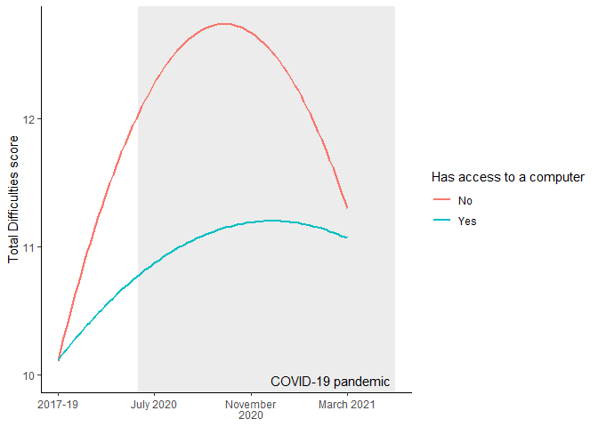

# Grouping by internet access

We now fit a new LGM with the participants grouped by whether or not they have access to a “good internet connection”.

```r
# Fitting free model
model_int_free <- '
i =~ 1*W9 + 1*CV4 + 1*CV6 + 1*CV8
s =~ 0*W9 + 1*CV4 + 2*CV6 + 3*CV8
q =~ 0*W9 + 1*CV4 + 4*CV6 + 9*CV8
'

fit_int_free <- growth(model_int_free, data = data_sdq[!is.na(data_sdq$ypschlth2),], group = "ypschlth2", missing = "fiml", estimator = "mlr")
summary(fit_int_free)
```

```
## lavaan 0.6-9 ended normally after 203 iterations
##
##   Estimator                                         ML
##   Optimization method                           NLMINB
##   Number of model parameters                        26
##
##   Number of observations per group:
##     1                                              746
##     0                                               90
##   Number of missing patterns per group:
##     1                                                7
##     0                                                5
##
## Model Test User Model:
##                                                Standard      Robust
##   Test Statistic                                  1.781       1.789
##   Degrees of freedom                                  2           2
##   P-value (Chi-square)                            0.410       0.409
##   Scaling correction factor                                   0.996
##        Yuan-Bentler correction (Mplus variant)
##   Test statistic for each group:
##     1                                            0.010       0.010
##     0                                            1.770       1.778
##
## Parameter Estimates:
##
##   Standard errors                             Sandwich
##   Information bread                           Observed
##   Observed information based on                Hessian
##
##
## Group 1 [1]:
##
## Latent Variables:
##                    Estimate  Std.Err  z-value  P(>|z|)
##   i =~
##     W9                1.000
##     CV4               1.000
##     CV6               1.000
##     CV8               1.000
```

[output cut: 72 more lines]

```
##    .CV6               0.000
##    .CV8               0.000
##     i                 9.156    0.661   13.853    0.000
##     s                 2.563    0.732    3.499    0.000
##     q                -0.583    0.189   -3.092    0.002
##
## Variances:
##                    Estimate  Std.Err  z-value  P(>|z|)
##    .W9               14.537   12.029    1.209    0.227
##    .CV4               8.536    2.953    2.891    0.004
##    .CV6              11.931    4.835    2.468    0.014
##    .CV8             -10.740   12.864   -0.835    0.404
##     i                13.897   12.503    1.112    0.266
##     s                 2.680   15.223    0.176    0.860
##     q                 0.583    0.861    0.677    0.498
```

```r
# Fitting model with constrained error variances
model_int_con_ervar <- '
i =~ 1*W9 + 1*CV4 + 1*CV6 + 1*CV8
s =~ 0*W9 + 1*CV4 + 2*CV6 + 3*CV8
q =~ 0*W9 + 1*CV4 + 4*CV6 + 9*CV8

W9 ~~ c(ervar1_1, ervar1_1)*W9
CV4 ~~ c(ervar2_1, ervar2_1)*CV4
CV6 ~~ c(ervar3_1, ervar3_1)*CV6
CV8 ~~ c(ervar4_1, ervar4_1)*CV8
'

fit_int_con_ervar <- growth(model_int_con_ervar, data = data_sdq[!is.na(data_sdq$ypschlth2),], group = "ypschlth2", missing = "fiml", estimator = "mlr")
# Comparing model with constrained error variances to free model
anova(fit_int_con_ervar, fit_int_free)
```

```
## Scaled Chi-Squared Difference Test (method = "satorra.bentler.2001")
##
## lavaan NOTE:
##     The "Chisq" column contains standard test statistics, not the
##     robust test that should be reported per model. A robust difference
##     test is a function of two standard (not robust) statistics.
##
##                   Df   AIC   BIC  Chisq Chisq diff Df diff Pr(>Chisq)
## fit_int_free       2 15926 16048 1.7809
## fit_int_con_ervar  6 15921 16025 5.5060     3.0105       4     0.5561
```

```r
# Accepting model with constrained error variances over free model

# Fitting model with constrained y-intercept
model_int_con_ervar_i <- '
i =~ 1*W9 + 1*CV4 + 1*CV6 + 1*CV8
s =~ 0*W9 + 1*CV4 + 2*CV6 + 3*CV8
q =~ 0*W9 + 1*CV4 + 4*CV6 + 9*CV8

W9 ~~ c(ervar1_1, ervar1_1)*W9
CV4 ~~ c(ervar2_1, ervar2_1)*CV4
CV6 ~~ c(ervar3_1, ervar3_1)*CV6
CV8 ~~ c(ervar4_1, ervar4_1)*CV8

i ~ c(i_1, i_1)*1
'

fit_int_con_ervar_i <- growth(model_int_con_ervar_i, data = data_sdq[!is.na(data_sdq$ypschlth2),], group = "ypschlth2", missing = "fiml", estimator = "mlr")
# Comparing model with constrained y-intercept to model without
anova(fit_int_con_ervar_i, fit_int_con_ervar)
```

```
## Scaled Chi-Squared Difference Test (method = "satorra.bentler.2001")
##
## lavaan NOTE:
##     The "Chisq" column contains standard test statistics, not the
##     robust test that should be reported per model. A robust difference
##     test is a function of two standard (not robust) statistics.
##
##                     Df   AIC   BIC  Chisq Chisq diff Df diff Pr(>Chisq)
## fit_int_con_ervar    6 15921 16025 5.5060
## fit_int_con_ervar_i  7 15920 16019 5.7588    0.25731       1      0.612
```

```r
# Accepting model with constrained y-intercept over model without

# Fitting model with constrained linear coefficient
model_int_con_ervar_i_s <- '
i =~ 1*W9 + 1*CV4 + 1*CV6 + 1*CV8
s =~ 0*W9 + 1*CV4 + 2*CV6 + 3*CV8
q =~ 0*W9 + 1*CV4 + 4*CV6 + 9*CV8

W9 ~~ c(ervar1_1, ervar1_1)*W9
CV4 ~~ c(ervar2_1, ervar2_1)*CV4
CV6 ~~ c(ervar3_1, ervar3_1)*CV6
CV8 ~~ c(ervar4_1, ervar4_1)*CV8

i ~ c(i_1, i_1)*1
s ~ c(s_1, s_1)*1
'

fit_int_con_ervar_i_s <- growth(model_int_con_ervar_i_s, data = data_sdq[!is.na(data_sdq$ypschlth2),], group = "ypschlth2", missing = "fiml", estimator = "mlr")
# Comparing model with constrained linear coefficient to model without
anova(fit_int_con_ervar_i_s, fit_int_con_ervar_i)
```

```
## Scaled Chi-Squared Difference Test (method = "satorra.bentler.2001")
##
## lavaan NOTE:
##     The "Chisq" column contains standard test statistics, not the
##     robust test that should be reported per model. A robust difference
##     test is a function of two standard (not robust) statistics.
##
##                       Df   AIC   BIC  Chisq Chisq diff Df diff Pr(>Chisq)
## fit_int_con_ervar_i    7 15920 16019 5.7588
## fit_int_con_ervar_i_s  8 15921 16016 9.3564     4.5178       1    0.03354 *
## ---
## Signif. codes:  0 '***' 0.001 '**' 0.01 '*' 0.05 '.' 0.1 ' ' 1
```

```r
# Rejecting model with constrained linear coefficient

# Fitting model with constrained quadratic coefficient
model_int_con_ervar_i_q <- '
i =~ 1*W9 + 1*CV4 + 1*CV6 + 1*CV8
s =~ 0*W9 + 1*CV4 + 2*CV6 + 3*CV8
q =~ 0*W9 + 1*CV4 + 4*CV6 + 9*CV8

W9 ~~ c(ervar1_1, ervar1_1)*W9
CV4 ~~ c(ervar2_1, ervar2_1)*CV4
CV6 ~~ c(ervar3_1, ervar3_1)*CV6
CV8 ~~ c(ervar4_1, ervar4_1)*CV8

i ~ c(i_1, i_1)*1
q ~ c(q_1, q_1)*1
'

fit_int_con_ervar_i_q <- growth(model_int_con_ervar_i_q, data = data_sdq[!is.na(data_sdq$ypschlth2),], group = "ypschlth2", missing = "fiml", estimator = "mlr")
# Comparing model with constrained quadratic coefficient to model without
anova(fit_int_con_ervar_i_q, fit_int_con_ervar_i)
```

```
## Scaled Chi-Squared Difference Test (method = "satorra.bentler.2001")
##
## lavaan NOTE:
##     The "Chisq" column contains standard test statistics, not the
##     robust test that should be reported per model. A robust difference
##     test is a function of two standard (not robust) statistics.
##
##                       Df   AIC   BIC  Chisq Chisq diff Df diff Pr(>Chisq)
## fit_int_con_ervar_i    7 15920 16019 5.7588
## fit_int_con_ervar_i_q  8 15920 16015 8.3867     3.0642       1    0.08004 .
## ---
## Signif. codes:  0 '***' 0.001 '**' 0.01 '*' 0.05 '.' 0.1 ' ' 1
```

```r
# Accepting model with constrained quadratic coefficient over model without
fit_int_prov <- fit_int_con_ervar_i_q

# Fitting model with constrained y-intercept variance
model_int_con_ivar <- '
i =~ 1*W9 + 1*CV4 + 1*CV6 + 1*CV8
s =~ 0*W9 + 1*CV4 + 2*CV6 + 3*CV8
q =~ 0*W9 + 1*CV4 + 4*CV6 + 9*CV8

W9 ~~ c(ervar1_1, ervar1_1)*W9
CV4 ~~ c(ervar2_1, ervar2_1)*CV4
CV6 ~~ c(ervar3_1, ervar3_1)*CV6
CV8 ~~ c(ervar4_1, ervar4_1)*CV8

i ~ c(i_1, i_1)*1
q ~ c(q_1, q_1)*1

i ~~ c(ivar_1, ivar_1)*i
'

fit_int_con_ivar <- growth(model_int_con_ivar, data = data_sdq[!is.na(data_sdq$ypschlth2),], group = "ypschlth2", missing = "fiml", estimator = "mlr")
# Comparing model with constrained y-intercept variance to model without
anova(fit_int_con_ivar, fit_int_prov)
```

```
## Scaled Chi-Squared Difference Test (method = "satorra.bentler.2001")
##
## lavaan NOTE:
##     The "Chisq" column contains standard test statistics, not the
##     robust test that should be reported per model. A robust difference
##     test is a function of two standard (not robust) statistics.
##
##                  Df   AIC   BIC  Chisq Chisq diff Df diff Pr(>Chisq)
## fit_int_prov      8 15920 16015 8.3867
## fit_int_con_ivar  9 15919 16009 8.9741    0.59027       1     0.4423
```

```r
# Accepting model with constrained y-intercept variance over model without

# Fitting model with constrained linear coefficient variance
model_int_con_ivar_svar <- '
i =~ 1*W9 + 1*CV4 + 1*CV6 + 1*CV8
s =~ 0*W9 + 1*CV4 + 2*CV6 + 3*CV8
q =~ 0*W9 + 1*CV4 + 4*CV6 + 9*CV8

W9 ~~ c(ervar1_1, ervar1_1)*W9
CV4 ~~ c(ervar2_1, ervar2_1)*CV4
CV6 ~~ c(ervar3_1, ervar3_1)*CV6
CV8 ~~ c(ervar4_1, ervar4_1)*CV8

i ~ c(i_1, i_1)*1
q ~ c(q_1, q_1)*1

i ~~ c(ivar_1, ivar_1)*i
s ~~ c(svar_1, svar_1)*s
'

fit_int_con_ivar_svar <- growth(model_int_con_ivar_svar, data = data_sdq[!is.na(data_sdq$ypschlth2),], group = "ypschlth2", missing = "fiml", estimator = "mlr")
# Comparing model with constrained linear coefficient variance to model without
anova(fit_int_con_ivar_svar, fit_int_con_ivar)
```

```
## Scaled Chi-Squared Difference Test (method = "satorra.bentler.2001")
##
## lavaan NOTE:
##     The "Chisq" column contains standard test statistics, not the
##     robust test that should be reported per model. A robust difference
##     test is a function of two standard (not robust) statistics.
##
##                       Df   AIC   BIC  Chisq Chisq diff Df diff Pr(>Chisq)
## fit_int_con_ivar       9 15919 16009 8.9741
## fit_int_con_ivar_svar 10 15917 16002 8.9743 9.8135e-05       1     0.9921
```

```r
# Accepting model with constrained linear coefficient variance over model without

# Fitting model with constrained quadratic coefficient variance
model_int_con_ivar_svar_qvar <- '
i =~ 1*W9 + 1*CV4 + 1*CV6 + 1*CV8
s =~ 0*W9 + 1*CV4 + 2*CV6 + 3*CV8
q =~ 0*W9 + 1*CV4 + 4*CV6 + 9*CV8

W9 ~~ c(ervar1_1, ervar1_1)*W9
CV4 ~~ c(ervar2_1, ervar2_1)*CV4
CV6 ~~ c(ervar3_1, ervar3_1)*CV6
CV8 ~~ c(ervar4_1, ervar4_1)*CV8

i ~ c(i_1, i_1)*1
q ~ c(q_1, q_1)*1

i ~~ c(ivar_1, ivar_1)*i
s ~~ c(svar_1, svar_1)*s
q ~~ c(qvar_1, qvar_1)*q
'

fit_int_con_ivar_svar_qvar <- growth(model_int_con_ivar_svar_qvar, data = data_sdq[!is.na(data_sdq$ypschlth2),], group = "ypschlth2", missing = "fiml", estimator = "mlr")

# Comparing model with constrained quadratic coefficient variance to model without
anova(fit_int_con_ivar_svar_qvar, fit_int_con_ivar_svar)
```

```
## Scaled Chi-Squared Difference Test (method = "satorra.bentler.2001")
##
## lavaan NOTE:
##     The "Chisq" column contains standard test statistics, not the
##     robust test that should be reported per model. A robust difference
##     test is a function of two standard (not robust) statistics.
##
##                            Df   AIC   BIC   Chisq Chisq diff Df diff Pr(>Chisq)
## fit_int_con_ivar_svar      10 15917 16002  8.9743
## fit_int_con_ivar_svar_qvar 11 15918 15998 11.8390     4.0723       1    0.04359
##
## fit_int_con_ivar_svar
## fit_int_con_ivar_svar_qvar *
## ---
## Signif. codes:  0 '***' 0.001 '**' 0.01 '*' 0.05 '.' 0.1 ' ' 1
```

```r
# Rejecting model with constrained quadratic coefficient variance
fit_int_prov <- fit_int_con_ivar_svar

# Fitting model with constrained y-intercept/linear coefficient covariance
model_int_con_iscovar <- '
i =~ 1*W9 + 1*CV4 + 1*CV6 + 1*CV8
s =~ 0*W9 + 1*CV4 + 2*CV6 + 3*CV8
q =~ 0*W9 + 1*CV4 + 4*CV6 + 9*CV8

W9 ~~ c(ervar1_1, ervar1_1)*W9
CV4 ~~ c(ervar2_1, ervar2_1)*CV4
CV6 ~~ c(ervar3_1, ervar3_1)*CV6
CV8 ~~ c(ervar4_1, ervar4_1)*CV8

i ~ c(i_1, i_1)*1
q ~ c(q_1, q_1)*1

i ~~ c(ivar_1, ivar_1)*i
s ~~ c(svar_1, svar_1)*s

i ~~ c(iscovar_1, iscovar_1)*s
'

fit_int_con_iscovar <- growth(model_int_con_iscovar, data = data_sdq[!is.na(data_sdq$ypschlth2),], group = "ypschlth2", missing = "fiml", estimator = "mlr")
# Comparing model with constrained y-intercept/linear coefficient covariance to model without
anova(fit_int_con_iscovar, fit_int_prov)
```

```
## Scaled Chi-Squared Difference Test (method = "satorra.bentler.2001")
##
## lavaan NOTE:
##     The "Chisq" column contains standard test statistics, not the
##     robust test that should be reported per model. A robust difference
##     test is a function of two standard (not robust) statistics.
##
##                     Df   AIC   BIC  Chisq Chisq diff Df diff Pr(>Chisq)
## fit_int_prov        10 15917 16002 8.9743
## fit_int_con_iscovar 11 15915 15995 9.1824    0.24279       1     0.6222
```

```r
# Accepting model with constrained y-intercept/linear coefficient covariance over model without

# Fitting model with constrained y-intercept/quadratic coefficient covariance
model_int_con_iscovar_iqcovar <- '
i =~ 1*W9 + 1*CV4 + 1*CV6 + 1*CV8
s =~ 0*W9 + 1*CV4 + 2*CV6 + 3*CV8
q =~ 0*W9 + 1*CV4 + 4*CV6 + 9*CV8

W9 ~~ c(ervar1_1, ervar1_1)*W9
CV4 ~~ c(ervar2_1, ervar2_1)*CV4
CV6 ~~ c(ervar3_1, ervar3_1)*CV6
CV8 ~~ c(ervar4_1, ervar4_1)*CV8

i ~ c(i_1, i_1)*1
q ~ c(q_1, q_1)*1

i ~~ c(ivar_1, ivar_1)*i
s ~~ c(svar_1, svar_1)*s

i ~~ c(iscovar_1, iscovar_1)*s
i ~~ c(iqcovar_1, iqcovar_1)*q
'

fit_int_con_iscovar_iqcovar <- growth(model_int_con_iscovar_iqcovar, data = data_sdq[!is.na(data_sdq$ypschlth2),], group = "ypschlth2", missing = "fiml", estimator = "mlr")
# Comparing model with constrained y-intercept/quadratic coefficient covariance to model without
anova(fit_int_con_iscovar_iqcovar, fit_int_con_iscovar)
```

```
## Scaled Chi-Squared Difference Test (method = "satorra.bentler.2001")
##
## lavaan NOTE:
##     The "Chisq" column contains standard test statistics, not the
##     robust test that should be reported per model. A robust difference
##     test is a function of two standard (not robust) statistics.
##
##                             Df   AIC   BIC   Chisq Chisq diff Df diff
## fit_int_con_iscovar         11 15915 15995  9.1824
## fit_int_con_iscovar_iqcovar 12 15915 15991 11.5220     2.4616       1
##                             Pr(>Chisq)
## fit_int_con_iscovar
## fit_int_con_iscovar_iqcovar     0.1167
```

```r
# Accepting model with constrained y-intercept/quadratic coefficient covariance over model without

# Fitting model with constrained linear coefficient/quadratic coefficient covariance
model_int_con_iscovar_iqcovar_sqcovar <- '
i =~ 1*W9 + 1*CV4 + 1*CV6 + 1*CV8
s =~ 0*W9 + 1*CV4 + 2*CV6 + 3*CV8
q =~ 0*W9 + 1*CV4 + 4*CV6 + 9*CV8

W9 ~~ c(ervar1_1, ervar1_1)*W9
CV4 ~~ c(ervar2_1, ervar2_1)*CV4
CV6 ~~ c(ervar3_1, ervar3_1)*CV6
CV8 ~~ c(ervar4_1, ervar4_1)*CV8

i ~ c(i_1, i_1)*1
q ~ c(q_1, q_1)*1

i ~~ c(ivar_1, ivar_1)*i
s ~~ c(svar_1, svar_1)*s

i ~~ c(iscovar_1, iscovar_1)*s
i ~~ c(iqcovar_1, iqcovar_1)*q
s ~~ c(sqcovar_1, sqcovar_1)*q
'

fit_int_con_iscovar_iqcovar_sqcovar <- growth(model_int_con_iscovar_iqcovar_sqcovar, data = data_sdq[!is.na(data_sdq$ypschlth2),], group = "ypschlth2", missing = "fiml", estimator = "mlr")

# Comparing model with constrained linear coefficient/quadratic coefficient covariance to model without
anova(fit_int_con_iscovar_iqcovar_sqcovar, fit_int_con_iscovar_iqcovar)
```

```
## Scaled Chi-Squared Difference Test (method = "satorra.bentler.2001")
##
## lavaan NOTE:
##     The "Chisq" column contains standard test statistics, not the
##     robust test that should be reported per model. A robust difference
##     test is a function of two standard (not robust) statistics.
##
##                                     Df   AIC   BIC  Chisq Chisq diff Df diff
## fit_int_con_iscovar_iqcovar         12 15915 15991 11.522
## fit_int_con_iscovar_iqcovar_sqcovar 13 15922 15993 19.883     11.803       1
##                                     Pr(>Chisq)
## fit_int_con_iscovar_iqcovar
## fit_int_con_iscovar_iqcovar_sqcovar  0.0005915 ***
## ---
## Signif. codes:  0 '***' 0.001 '**' 0.01 '*' 0.05 '.' 0.1 ' ' 1
```

```r
# Rejecting model with constrained linear coefficient/quadratic coefficient covariance
fit_int <- growth(model_int_con_iscovar_iqcovar, data = data_sdq[!is.na(data_sdq$ypschlth2),], group = "ypschlth2", missing = "fiml")
# Summary of unweighted model
summary(fit_int)
```

```
## lavaan 0.6-9 ended normally after 122 iterations
##
##   Estimator                                         ML
##   Optimization method                           NLMINB
##   Number of model parameters                        26
##   Number of equality constraints                    10
##
##   Number of observations per group:
##     1                                              746
##     0                                               90
##   Number of missing patterns per group:
##     1                                                7
##     0                                                5
##
## Model Test User Model:
##
##   Test statistic                                11.522
##   Degrees of freedom                                12
##   P-value (Chi-square)                           0.485
##   Test statistic for each group:
##     1                                            1.209
##     0                                           10.313
##
## Parameter Estimates:
##
##   Standard errors                             Standard
##   Information                                 Observed
##   Observed information based on                Hessian
##
##
## Group 1 [1]:
##
## Latent Variables:
##                    Estimate  Std.Err  z-value  P(>|z|)
##   i =~
##     W9                1.000
##     CV4               1.000
##     CV6               1.000
##     CV8               1.000
##   s =~
```

[output cut: 71 more lines]

```
##    .W9                0.000
##    .CV4               0.000
##    .CV6               0.000
##    .CV8               0.000
##     s                 1.485    0.319    4.658    0.000
##
## Variances:
##                    Estimate  Std.Err  z-value  P(>|z|)
##    .W9      (e1_1)    9.775    3.832    2.551    0.011
##    .CV4     (e2_1)   10.080    1.134    8.891    0.000
##    .CV6     (e3_1)    8.561    1.133    7.553    0.000
##    .CV8     (e4_1)    4.730    3.268    1.447    0.148
##     i       (iv_1)   21.492    4.022    5.343    0.000
##     s       (sv_1)    9.322    4.744    1.965    0.049
##     q                -0.032    0.326   -0.099    0.921
```

```r
# Applying weights to model
fit_int_weighted <- lavaan.survey(fit_int, survey_design, estimator = "ML")
# Summary of weighted model
summary(fit_int_weighted)
```

```
## lavaan 0.6-9 ended normally after 116 iterations
##
##   Estimator                                         ML
##   Optimization method                           NLMINB
##   Number of model parameters                        26
##   Number of equality constraints                    10
##
##   Number of observations per group:
##     Group 1                                        746
##     Group 2                                         90
##
## Model Test User Model:
##
##   Test statistic                                49.421
##   Degrees of freedom                                12
##   P-value (Chi-square)                           0.000
##   Test statistic for each group:
##     Group 1                                     10.087
##     Group 2                                     39.334
##
## Parameter Estimates:
##
##   Standard errors                             Standard
##   Information                                 Observed
##   Observed information based on                Hessian
##
##
## Group 1 [Group 1]:
##
## Latent Variables:
##                    Estimate  Std.Err  z-value  P(>|z|)
##   i =~
##     W9                1.000
##     CV4               1.000
##     CV6               1.000
##     CV8               1.000
##   s =~
##     W9                0.000
##     CV4               1.000
##     CV6               2.000
```

[output cut: 68 more lines]

```
##    .W9                0.000
##    .CV4               0.000
##    .CV6               0.000
##    .CV8               0.000
##     s                 1.215    0.277    4.387    0.000
##
## Variances:
##                    Estimate  Std.Err  z-value  P(>|z|)
##    .W9      (e1_1)   10.736    2.402    4.471    0.000
##    .CV4     (e2_1)    6.320    0.809    7.814    0.000
##    .CV6     (e3_1)    8.987    0.916    9.806    0.000
##    .CV8     (e4_1)    0.783    2.495    0.314    0.754
##     i       (iv_1)   20.624    2.550    8.088    0.000
##     s       (sv_1)    6.823    2.964    2.302    0.021
##     q                 0.153    0.230    0.663    0.508
```

```r
# Saving model fit object
saveRDS(fit_int_weighted, file = "Data/Objects/int_nocov.rds")

# Preparing LGM functions for plotting
pT <- parTable(fit_int_weighted)
fit_int_fn0 <- function(x) pT[pT$lhs == "i" & pT$op == "~1" & pT$group == 2,]$est + pT[pT$lhs == "s" & pT$op == "~1" & pT$group == 2,]$est*x + pT[pT$lhs == "q" & pT$op == "~1" & pT$group == 2,]$est*x^2
fit_int_fn1 <- function(x) pT[pT$lhs == "i" & pT$op == "~1" & pT$group == 1,]$est + pT[pT$lhs == "s" & pT$op == "~1" & pT$group == 1,]$est*x + pT[pT$lhs == "q" & pT$op == "~1" & pT$group == 1,]$est*x^2
```

### Final LGM

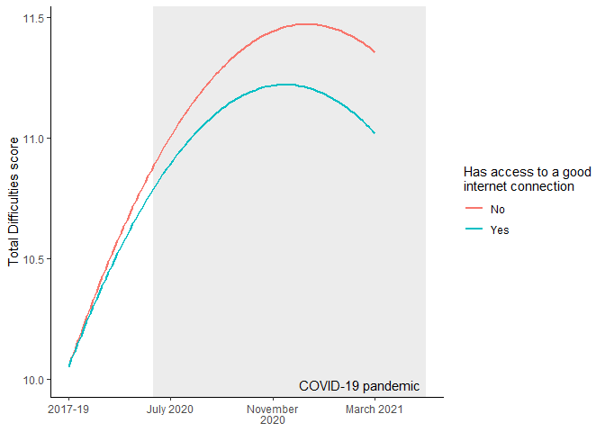